# reg_anova_workshop

### Resumen de Regresión Lineal

La **regresión lineal** es una técnica estadística que modela la relación entre una variable dependiente ($y$) y una o más variables independientes ($x$), utilizando una ecuación lineal:

$$ y = \beta_0 + \beta_1 x_1 + \beta_2 x_2 + \dots + \beta_k x_k + \epsilon $$

Donde:

- $\beta_0$ es el intercepto o término independiente.
- $\beta_1, \beta_2, \dots, \beta_k$ son los coeficientes asociados a las variables independientes.
- $\epsilon$ es el término de error, que representa la variabilidad no explicada.

### Análisis de los Coeficientes

Los coeficientes $\beta_i$ indican la magnitud y la dirección del efecto de cada variable independiente sobre la variable dependiente:

1. **Magnitud**:
   - Un coeficiente grande implica un cambio significativo en $y$ por cada unidad de cambio en $x_i$, manteniendo las demás variables constantes.
2. **Signo**:
   - $\beta_i > 0$: Relación positiva (al aumentar $x_i$, $y$ también aumenta).
   - $\beta_i < 0$: Relación negativa (al aumentar $x_i$, $y$ disminuye).
3. **Significancia**:
   - Se evalúa mediante pruebas de hipótesis ($H_0: \beta_i = 0$) usando el valor $p$. Si $p < 0.05$, el coeficiente se considera significativo.
4. **Interpretación en regresión simple**:
   - $\beta_1$: Representa el cambio promedio en $y$ por cada unidad de $x$.
5. **Interpretación en regresión múltiple**:
   - $\beta_i$: Representa el cambio en $y$ cuando $x_i$ cambia en una unidad, manteniendo las demás variables constantes.

### Supuestos del Modelo de Regresión Lineal

Para que los resultados de la regresión sean válidos, se deben cumplir ciertos supuestos:

1. **Linealidad**:
   - La relación entre $y$ y $x_i$ debe ser lineal. Esto puede verificarse visualizando los residuos vs. los valores predichos.

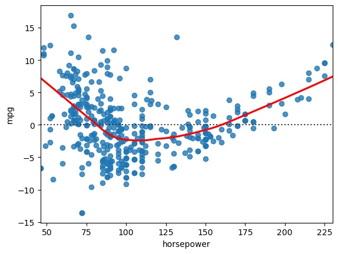

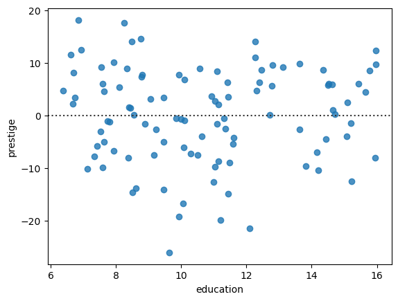

2. **Independencia de los Errores**:
   - Los errores ($\epsilon$) deben ser independientes entre sí.
3. **Homoscedasticidad**:
   - La varianza de los errores debe ser constante para todos los valores de $x$. Si los residuos muestran un patrón (e.g., cono), hay heteroscedasticidad.

[figure not shown]

4. **Normalidad de los Errores**:
   - Los errores deben seguir una distribución normal. Se puede verificar con:
     - Gráfico Q-Q (Quantile-Quantile).
     - Pruebas de normalidad como Shapiro-Wilk.

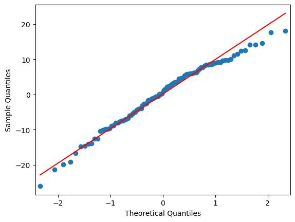

5. **No Colinealidad (en regresión múltiple)**:
   - Las variables independientes no deben estar altamente correlacionadas entre sí, ya que esto puede distorsionar los coeficientes ($VIF > 10$ indica colinealidad).

### Evaluación del Modelo

1. **$R^2$**: Mide el porcentaje de variabilidad de $y$ explicado por $x$. Un $R^2$ alto indica un buen ajuste, pero no necesariamente un modelo adecuado.
2. **$R^2$ Ajustado**: Similar a $R^2$, pero penaliza por el número de variables en el modelo, útil para regresión múltiple.
3. **Prueba F**: Evalúa si el modelo global es significativo ($H_0: \beta_1 = \beta_2 = \dots = \beta_k = 0$).
4. **Análisis de Residuos**: Residuos (diferencias entre valores observados y predichos) se analizan para detectar violaciones a los supuestos.

### Interpretación y Acción

- Si los coeficientes son significativos y los supuestos se cumplen, el modelo puede ser usado para predicción o inferencia.
- Si los supuestos no se cumplen, considera transformaciones (e.g., logaritmos, polinomios) o métodos alternativos como regresión robusta o no lineal.
  - Ver: https://marsgr6.github.io/ml-online/

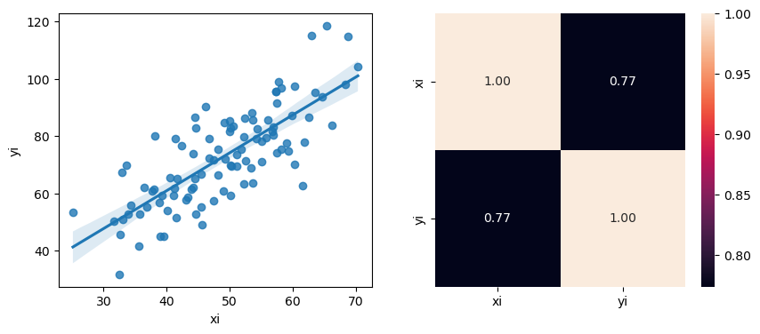

```python
import pandas as pd
import seaborn as sns
import matplotlib.pyplot as plt
import warnings
warnings.filterwarnings('ignore')

df = pd.read_csv("https://raw.githubusercontent.com/marsgr6/r-scripts/master/data/data_gd_demo.csv", header=None)
df.columns = ['xi', 'yi']

plt.figure(figsize=(10,4))
plt.subplot(1,2,1)
sns.regplot(data=df, x='xi', y='yi')
plt.subplot(1,2,2)
sns.heatmap(df.corr(), annot=True, fmt=".2f")
```

```python
import statsmodels.api as sm
from statsmodels.formula.api import ols
# We will model: income ~ education
# fit simple linear regression model
linear_model = ols('yi ~ xi',
                   data=df).fit()

# display model summary
print(linear_model.summary())
```

```
                            OLS Regression Results
==============================================================================
Dep. Variable:                     yi   R-squared:                       0.599
Model:                            OLS   Adj. R-squared:                  0.595
Method:                 Least Squares   F-statistic:                     146.2
Date:                Wed, 11 Dec 2024   Prob (F-statistic):           3.86e-21
Time:                        23:30:47   Log-Likelihood:                -377.03
No. Observations:                 100   AIC:                             758.1
Df Residuals:                      98   BIC:                             763.3
Df Model:                           1
Covariance Type:            nonrobust
==============================================================================
                 coef    std err          t      P>|t|      [0.025      0.975]
------------------------------------------------------------------------------
Intercept      7.9910      5.459      1.464      0.146      -2.842      18.824
xi             1.3224      0.109     12.090      0.000       1.105       1.539
==============================================================================
Omnibus:                        0.674   Durbin-Watson:                   2.151
Prob(Omnibus):                  0.714   Jarque-Bera (JB):                0.808
Skew:                           0.148   Prob(JB):                        0.668
Kurtosis:                       2.674   Cond. No.                         257.
==============================================================================

Notes:
[1] Standard Errors assume that the covariance matrix of the errors is correctly specified.
```

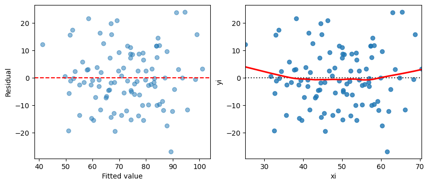

```python
# Predicted output (model: y=ax+b)
predictions = linear_model.predict(df.xi)
residuos = df.yi - predictions

plt.figure(figsize=(10,4))
plt.subplot(1,2,1)
plt.scatter(predictions, residuos, alpha=0.5)
plt.axhline(y=0, ls="--", c="r")
plt.xlabel("Fitted value")
plt.ylabel("Residual")

plt.subplot(1,2,2)
sns.residplot(data=df, x="xi", y="yi", lowess=True, line_kws=dict(color="r"))
```

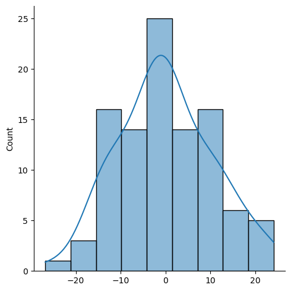

```python
sns.displot(residuos, kde=True)
```

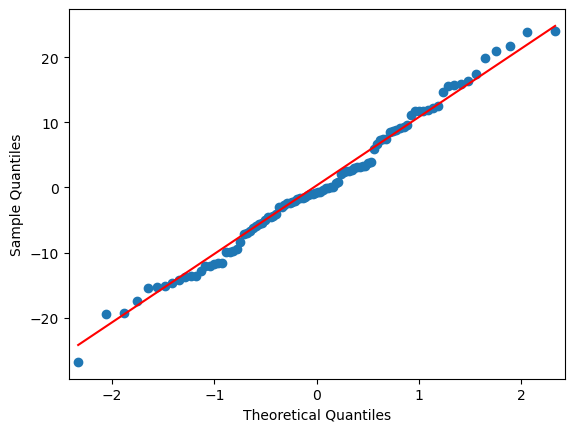

```python
fig = sm.qqplot(linear_model.resid, line='q')
```

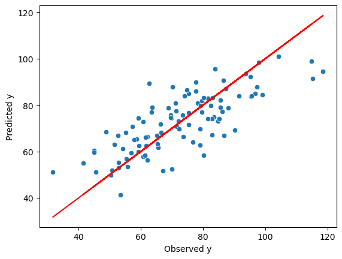

```python
sns.scatterplot(y=predictions, x=df.yi)
plt.plot(df.yi, df.yi, '-r')
plt.ylabel("Predicted y");
plt.xlabel("Observed y");
```

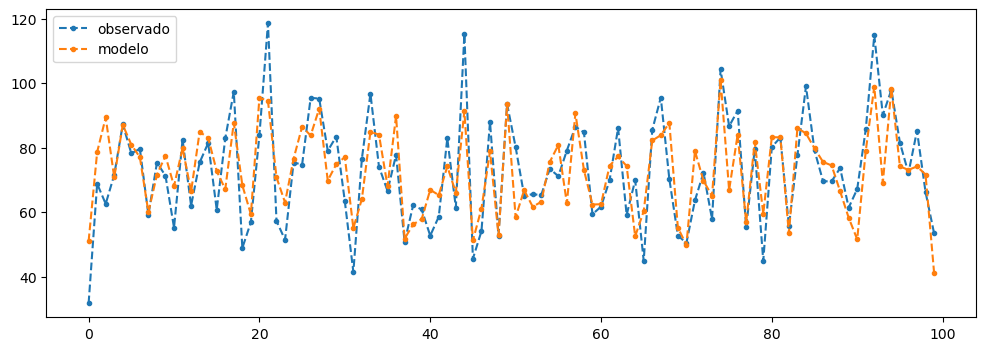

```python
plt.figure(figsize=(12,4))
plt.plot(df.yi, '--.', label="observado")
plt.plot(predictions, '--.', label="modelo")
plt.legend()
```

### Resumen de ANOVA (Análisis de Varianza)

El **ANOVA** (Analysis of Variance) es una técnica estadística utilizada para comparar las medias de tres o más grupos y determinar si existen diferencias significativas entre ellas. ANOVA analiza la variabilidad dentro y entre grupos para evaluar si las diferencias observadas son estadísticamente significativas.

### Tipos de ANOVA

1. **ANOVA de una vía (One-Way ANOVA)**:
   - Compara las medias de un factor categórico con varios niveles (grupos).
2. **ANOVA de dos vías (Two-Way ANOVA)**:
   - Examina dos factores simultáneamente, con o sin interacción entre ellos.
3. **ANOVA con medidas repetidas**:
   - Analiza datos en los que las mismas unidades están medidas en diferentes condiciones o momentos.

### Hipótesis

- **Hipótesis nula ($H_0$)**: Las medias de los grupos son iguales: $\mu_1 = \mu_2 = \dots = \mu_k$.
- **Hipótesis alternativa ($H_a$)**: Al menos una media es diferente.

### Componentes de Variabilidad

El ANOVA divide la variabilidad total ($SST$) en dos componentes principales:

1. **Variabilidad entre grupos ($SSB$)**:
   - Variabilidad explicada por las diferencias entre las medias de los grupos.
2. **Variabilidad dentro de grupos ($SSW$)**:
   - Variabilidad debida a las diferencias dentro de cada grupo.

La estadística $F$ se calcula como: $$ F = \frac{\text{MSB}}{\text{MSW}} $$ Donde:

- $\text{MSB} = \frac{SSB}{k-1}$ (Media de cuadrados entre grupos).
- $\text{MSW} = \frac{SSW}{n-k}$ (Media de cuadrados dentro de grupos).

Un $F$ alto sugiere que las diferencias entre grupos no son debidas al azar.

### Supuestos de ANOVA

Para que los resultados de ANOVA sean válidos, se deben cumplir los siguientes supuestos:

1. **Independencia de las Observaciones**:
   - Los datos de cada grupo deben ser independientes entre sí.
2. **Normalidad**:
   - Las distribuciones dentro de cada grupo deben ser aproximadamente normales. Esto se evalúa mediante:
     - Gráficos Q-Q.
     - Pruebas de normalidad (Shapiro-Wilk, Kolmogorov-Smirnov).
3. **Homoscedasticidad (Igualdad de Varianzas)**:
   - Las varianzas de los grupos deben ser iguales.
   - Se evalúa con pruebas como Levene o Bartlett.

### Pasos para Realizar ANOVA

1. **Plantear la hipótesis nula y alternativa**.
2. **Calcular la estadística $F$**:
   - Dividiendo la variabilidad entre grupos ($MSB$) por la variabilidad dentro de grupos ($MSW$).
3. **Evaluar el valor $p$**:
   - Si $p < 0.05$, se rechaza $H_0$, indicando diferencias significativas.
4. **Realizar pruebas post hoc** (si se rechaza $H_0$):
   - Para identificar qué grupos son diferentes (e.g., Tukey, Bonferroni).

### Interpretación de Resultados

1. **Estadística $F$**:
   - Un $F$ alto sugiere que las diferencias entre grupos son significativas.
2. **Valor $p$**:
   - Si $p < 0.05$: Existe evidencia significativa para rechazar $H_0$.
   - Si $p \geq 0.05$: No se rechaza $H_0$; no hay diferencias significativas.
3. **Pruebas post hoc**:
   - Identifican específicamente qué pares de grupos difieren.

### Aplicaciones de ANOVA

- Comparación de tratamientos en estudios experimentales.
- Evaluación de diferencias entre grupos en encuestas o estudios de mercado.
- Pruebas de hipótesis en análisis usabilidad y diferencias entre grupos de usuarios.

Al cumplir los supuestos y analizar los resultados cuidadosamente, ANOVA es una herramienta poderosa para evaluar diferencias entre grupos.

### Ejemplo en Python

```python
import pandas as pd
import scipy.stats as stats
from statsmodels.stats.multicomp import pairwise_tukeyhsd

social_media_usage = pd.read_csv("https://raw.githubusercontent.com/marsgr6/estadistica-ux/main/data/sm_usage.csv")
social_media_usage.groupby('RACE').describe()['MINUTES']
```

| RACE | count | mean | std | min | 25% | 50% | 75% | max |
| --- | --- | --- | --- | --- | --- | --- | --- | --- |
| American Indian/Aleut/Eskimo | 655.0 | 39.444275 | 10.570697 | 0.0 | 40.0 | 40.0 | 40.00 | 92.0 |
| Asian/Pacific Islander | 4043.0 | 40.402671 | 10.441899 | 0.0 | 40.0 | 40.0 | 40.00 | 110.0 |
| Black | 5546.0 | 40.088172 | 9.876312 | 0.0 | 40.0 | 40.0 | 40.00 | 100.0 |
| Other | 820.0 | 40.735366 | 11.356772 | 0.0 | 40.0 | 40.0 | 42.25 | 99.0 |
| White | 41242.0 | 40.640124 | 11.398309 | 0.0 | 40.0 | 40.0 | 45.00 | 180.0 |

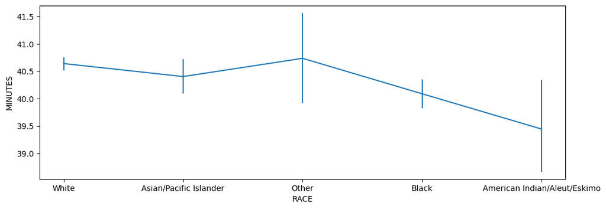

```python
plt.figure(figsize=(12,4))
sns.lineplot(data=social_media_usage, x="RACE", y="MINUTES", err_style="bars")
```

```python
import statsmodels.api as sm
from statsmodels.formula.api import ols

model = ols('MINUTES ~ RACE',  # Model formula
            data = social_media_usage).fit()

anova_result = sm.stats.anova_lm(model, typ=2)
print(anova_result)
```

```
                sum_sq       df         F    PR(>F)
RACE      2.434614e+03      4.0  4.883604  0.000618
Residual  6.518380e+06  52301.0       NaN       NaN
```

```python
from statsmodels.stats.multicomp import pairwise_tukeyhsd

tukey = pairwise_tukeyhsd(endog=social_media_usage.MINUTES,     # Data
                          groups=social_media_usage.RACE,   # Groups
                          alpha=0.1)          # Significance level

tukey.summary()
```

Multiple Comparison of Means - Tukey HSD, FWER=0.10

| group1 | group2 | meandiff | p-adj | lower | upper | reject |
| --- | --- | --- | --- | --- | --- | --- |
| American Indian/Aleut/Eskimo | Asian/Pacific Islander | 0.9584 | 0.2477 | -0.1981 | 2.1149 | False |
| American Indian/Aleut/Eskimo | Black | 0.6439 | 0.6303 | -0.4906 | 1.7784 | False |
| American Indian/Aleut/Eskimo | Other | 1.2911 | 0.1771 | -0.1479 | 2.73 | False |
| American Indian/Aleut/Eskimo | White | 1.1958 | 0.0511 | 0.1145 | 2.2772 | True |
| Asian/Pacific Islander | Black | -0.3145 | 0.6519 | -0.8823 | 0.2533 | False |
| Asian/Pacific Islander | Other | 0.3327 | 0.937 | -0.719 | 1.3843 | False |
| Asian/Pacific Islander | White | 0.2375 | 0.697 | -0.2151 | 0.69 | False |
| Black | Other | 0.6472 | 0.5301 | -0.3801 | 1.6745 | False |
| Black | White | 0.552 | 0.005 | 0.1592 | 0.9447 | True |
| Other | White | -0.0952 | 0.9992 | -1.0636 | 0.8731 | False |

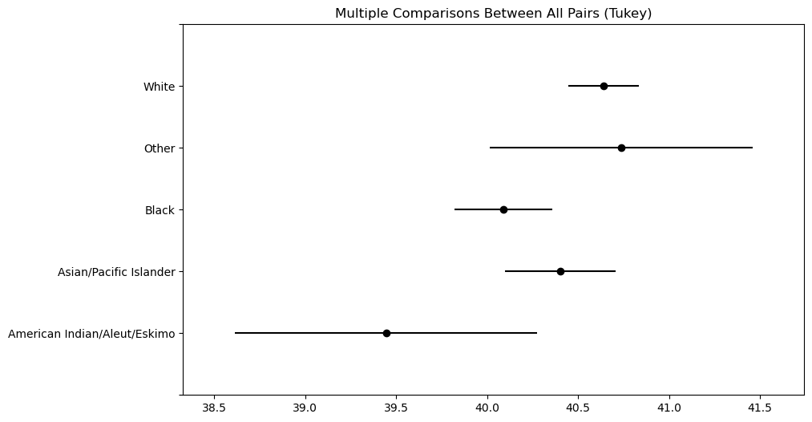

```python
tukey.plot_simultaneous();    # Plot group confidence intervals
```